# This Means (Bayesian) War(fare)!

A Bayesian Neural Network Approach to Electronic Warfare

Author

Maggie Morrison and Joshua DiLena (Advisor: Dr. Cohen)

Published

October 18, 2026

Slides: slides.html

## Introduction

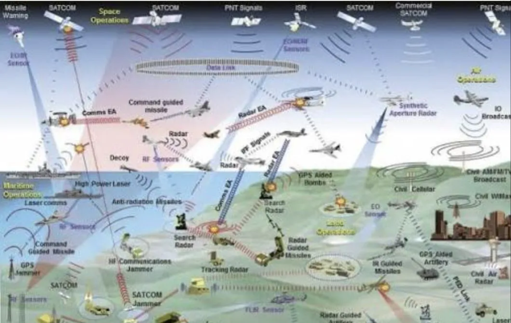

Figure 1: EW Visual

The military has been using Electronic Warfare (EW) since World War I (*Electronic Warfare*, n.d.). With recent technological advances, EW will continue to evolve; most recently, through the military use of drones, which depend on reliable radio frequency (RF) links and are vulnerable to jamming and interference (vgi_admin 2025). Recently, machine learning is used to address these threats. For example, Jere et al. combined supervised learning with Bayesian network inference to detect and classify jamming in 5G New Radio networks in near real time (Jere et al. 2024). That work shows that Bayesian methods can utilize machine learning models in wireless security which will be more accurate and more interpretable (Jere et al. 2024). The selection of a signal dataset that supports both neural network modeling and Bayesian analysis to predict signal-to-noise ratio (SNR) and examine how signal quality varies across conditions (Jere et al. 2024).

Our project uses the DeepSig RadioML 2018.01A dataset, downloaded from Kaggle, containing simulated RF signals across different modulation types with varying levels of noise (O’Shea et al. 2018). The dataset includes 24 modulation types, 26 SNR levels ranging from −20 dB to +30 dB, and 1,024 in-phase and quadrature (I/Q) samples per signal, for approximately 5,000 total observations (O’Shea et al. 2018). It therefore provides a useful schema for studying how signal quality changes under different interference conditions (O’Shea et al. 2018).

The objective of this project is to model SNR as the response variable using neural networks and Bayesian analysis. Bayesian methods treat model parameters as probability distributions rather than fixed values. This allows prior knowledge to be formally incorporated and results to be expressed as direct probability statements about quantities of interest (Berger 2000). Applied to neural networks, the Bayesian framework has a solution to overfitting and ways to quantify uncertainty in predictions (Bishop 1997). In addition, Bayesian neural networks are better than standard networks when data are noisy, because Bayesian neural networks reports show how confident each prediction is (Mullachery et al. 2018). Guidance on using these models with deep learning tools is explained by Jospin et al. Because the dataset is large, scalability is an important consideration (Jospin et al. 2022). Hernández-Lobato et al. studied that “probabilistic backpropagation allows Bayesian neural networks to be trained efficiently on large datasets while retaining accurate uncertainty estimates” (Hernandez-Lobato and Adams 2015).

Because our dataset DeepSig 2018 contains a large number of raw signal measurements, feature engineering techniques will be applied to summarize the I/Q components into meaningful predictors. It might be seen that some of the predictors are correlated with one another, so factor sensitivity analysis using Bayesian neural networks will identify which inputs strongly influence the predicted SNR (Bai et al. 2009). Model performance will be evaluated using statistics metrics such as mean squared error (MSE). Comparisons will be made to assess how well regularization methods commonly used in neural networks handle multicollinearity and improve prediction accuracy. In the Bayesian setting, prior distributions on network weights act as a natural form of regularization, comparable to weight decay in conventional networks (Bishop 1997). Finally, Bayesian optimization will be considered for tuning model hyperparameters. Prior work shows that it can find strong configurations with fewer training runs than grid or random search (Snoek et al. 2015).

## Methods

### Data Cleaning

All input features were first scaled down by subtracting the feature’s mean from each value, then dividing by the feature’s standard deviation. Then all features were separated into either the training set or testing set so that our model would not be overfit. During this process, 70% of the data was held for training the model and 30% was used for testing the model’s performance later on.

Multicollinearity testing showed that IQ_Power is an exact linear combination of two other predictors: IQ_Power = I_Power + Q_Power. The IQ_Power definition, is the total power of a baseband signal is the sum of its in-phase and quadrature channel powers (O’Shea and Hoydis 2017). The column means in Table 2 confirm the identity (2.598 + 2.612 = 5.210), and the alias() function in R flagged the exact dependence. Because a linear dependence will make the design matrix rank-deficient and the coefficients non-identifiable, IQ_Power was removed. IQ_mean and IQ_sd were retained. The IQ_mean and the IQ_sd are nonlinear functions of the I/Q samples, so they are correlated with the power features but not linearly dependent on them.

### Model Compilation

A Bayesian Neural Network was created with 5 hidden layers and 1 output layer, where the output layer is the predicted mean and standard deviation. The model was created using Tensorflow’s Sequential model and each layer is comprised of Tensorflow_Probability’s DenseFlipout layer with varying numbers of nodes and each having a relu activation function.

$$\operatorname{ReLU}(x) =
\begin{cases}
0, & x \leq 0, \\
x, & x > 0.
\end{cases}$$

The Loss Function used during the model compilation was a negative log-likelihood function (seen below).

$$\mathcal{L} =
\frac{1}{2}\log(2\pi\sigma^2)
+
\frac{(y-\mu)^2}{2\sigma^2}$$

where:

- $y$ is the observed target value.
- $\mu$ is the predicted mean.
- $\sigma$ is the predicted standard deviation.
- $\sigma^2$ is the predicted variance.

An Adam (Adaptive Moment Estimation) optimizer was used during the training of the model and both Mean Square Error (MSE) and Mean Absolute Error (MAE) were used as metrics to judge model performance.

### Model Training

The model was trained on the previously mentioned training data over 200 epochs. A validation dataset (20% of the training data) was witheld in each iteration so that the model could be diagnosed as overfitting, if applicable. Then, in order to find a scope of distributions the true distribution might be, this process was repeated 200 times and each of those probability density functions can be found at Figure 5. An average of the means and standard deviations were then taken to find an overall mean and standard deviation, shown in Figure 6.

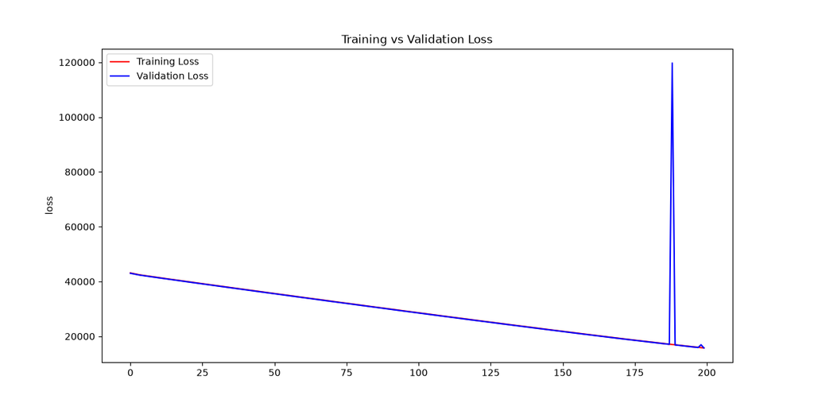

Figure 2: Loss

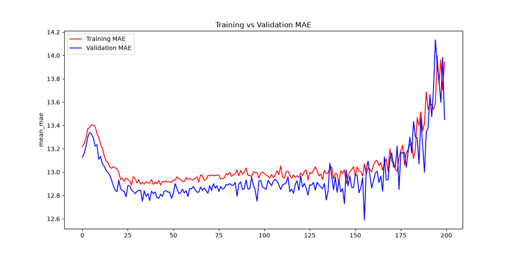

Figure 3: MAE

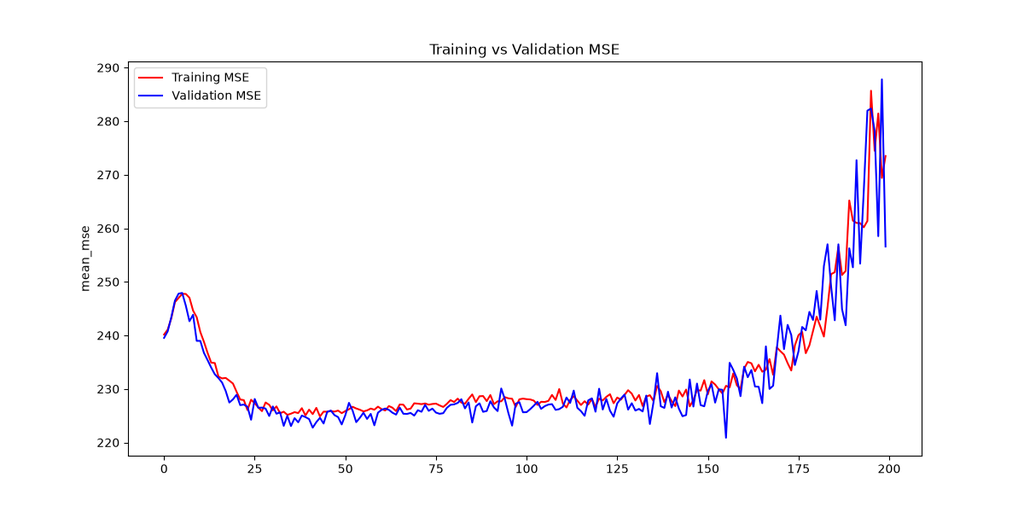

Figure 4: MSE

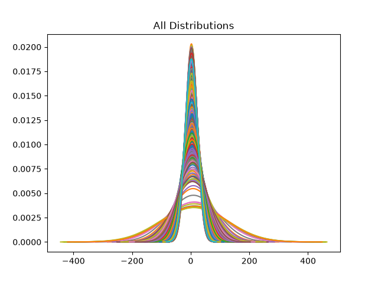

Figure 5: All Distributions

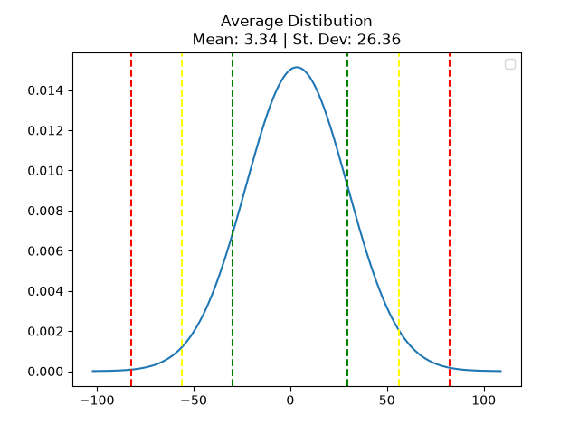

Figure 6: Final Distribution

## Analysis and Results

### Data Exploration and Visualization

#### Variable Descriptions

Table 1: Feature definitions and categories

| Variable Name | Type | Feature Type | Description |
| --- | --- | --- | --- |
| SNR | Numeric | Response | Signal-to-noise ratio (target variable) |
| I_mean | Numeric | **Time-domain | Mean of in-phase signal |
| Q_mean | Numeric | **Time-domain | Mean of quadrature signal |
| IQ_mean | Numeric | **Time-domain | Mean of the signal magnitude across the 1,024 samples: $\text{IQ\_mean} = \frac{1}{N}\sum_{n=1}^{N} \|x_n\|$ |
| I_var | Numeric | **Time-domain | Variance of I component |
| Q_var | Numeric | **Time-domain | Variance of Q component |
| I_Power | Numeric | **Time-domain | Average power of I signal |
| Q_Power | Numeric | **Time-domain | Average power of Q signal |
| *IQ_Power | Numeric | Combined | Total signal power from I and Q |
| IQ_sd | Numeric | Combined | Standard deviation of signal magnitude: $\text{IQ\_sd} = \sqrt{\frac{1}{N}\sum_{n=1}^{N}\big(\|x_n\| - \text{IQ\_mean}\big)^2}$ |
| Modulation | Categorical | Categorical | Type of modulation (e.g., QPSK, BPSK) |

* `IQ_Power` was subsequently removed during preprocessing due to perfect collinearity with `I_Power` and `Q_Power`.

** Features were categorized into time-domain, combined signal, and distribution-based groups to better capture different aspects of the RF signal behavior and support interpretation of model performance.

#### Variable General Statistics

```python
from General_Statistics import table
import pandas as pd

pd.set_option("display.width", 2000)
pd.set_option("display.max_columns", None)
print(table)
```

Table 2

```
       Feature        Min  1st Quartile     Median       Mean  3rd Quartile         Max
0       I_mean -16.722240     -0.030249   0.000263   0.018516      0.032257   19.778996
1       Q_mean -23.501888     -0.030092   0.000146   0.003714      0.030859   23.791832
2        I_var   0.000815      0.472972   0.497107   0.487508      0.518555    1.493720
3        Q_var   0.000233      0.473763   0.497583   0.491046      0.519563    1.485343
4         I_sd   0.028544      0.687730   0.705058   0.686819      0.720108    1.222179
5         Q_sd   0.015251      0.688304   0.705396   0.690283      0.720807    1.218746
6      I_power   0.000815      0.482464   0.503780   2.598423      0.534400  391.883900
7      Q_power   0.000233      0.482857   0.503935   2.612191      0.533632  566.978150
8     IQ_power   0.808317      0.989295   1.007101   5.210613      1.034881  676.398250
9      IQ_mean   0.806417      0.888267   0.910808   1.279394      0.957064   25.983335
10       IQ_sd   0.003528      0.380434   0.449468   0.447166      0.468093    1.265378
11         SNR -20.000000     -8.000000   4.000000   4.336800     16.000000   30.000000
12  Modulation   0.000000      6.000000  12.000000  11.663200     18.000000   23.000000
```

[figure not shown]

Figure 7: Density Power Plot

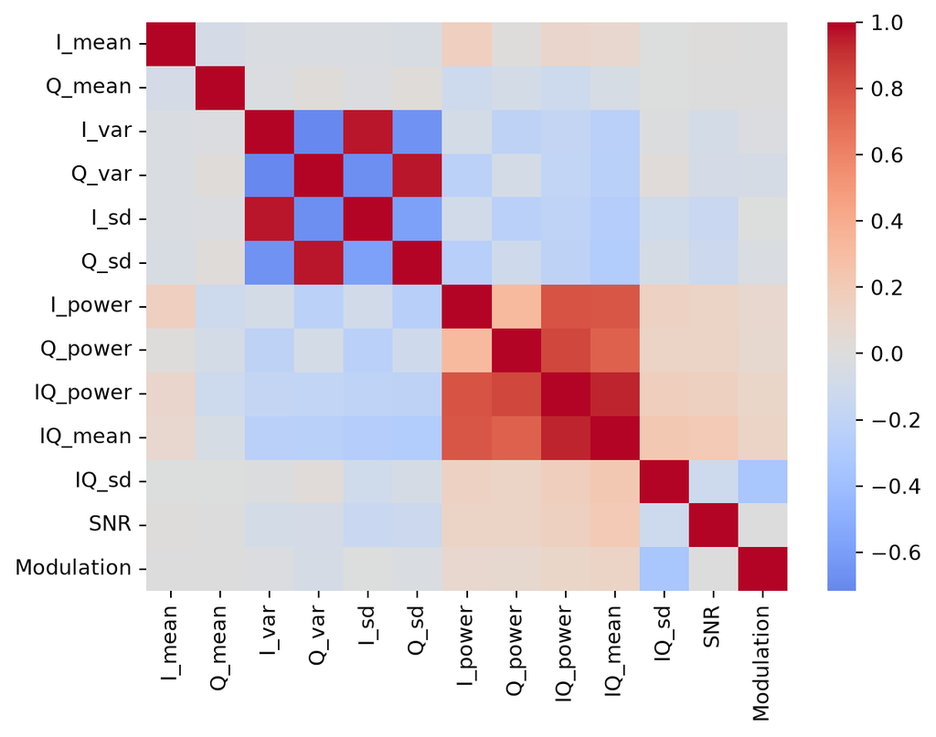

Figure 8: Correlation Heatmap of all Variables

```python
import pandas as pd
import numpy as np
import matplotlib.pyplot as plt
import seaborn as sns
data = pd.read_csv("radioml_features.csv")

sns.heatmap(data.corr(),cmap="coolwarm",center=0)
```

Histograms are shown to display the distribution of our Signal-to-Noise (SNR) Ratios and Modulation values in our dataset (Figure 9 and Figure 10, respectively)

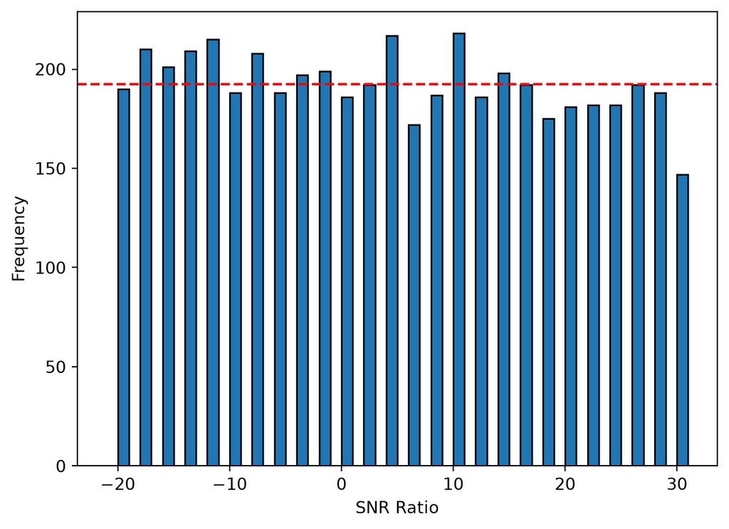

Figure 9: Distribution of Signal-to-Noise Ratio in the RadioML dataset

```python
import pandas as pd
import numpy as np
import matplotlib.pyplot as plt
data = pd.read_csv("radioml_features.csv")

bins1 = np.arange(min(data['SNR'].to_numpy())-1,max(data["SNR"].to_numpy())+2)


plt.hist(data['SNR'].to_numpy(),bins=bins1,edgecolor='black')
counts = []
for val in list(set(data["SNR"].to_numpy())):
  counts.append(list(data["SNR"].to_numpy()).count(val))
plt.ylabel("Frequency")
plt.xlabel("SNR Ratio")
plt.axhline(np.array(counts).mean(),-30,30,linestyle='--',color='red')
#plt.title("Response Variable (Signal-to-Noise Ratio) Distribution")
plt.show()
```

The SNR distribution has 26 discrete levels from -20dB to +30dB, visually appears to look like a uniform distribution

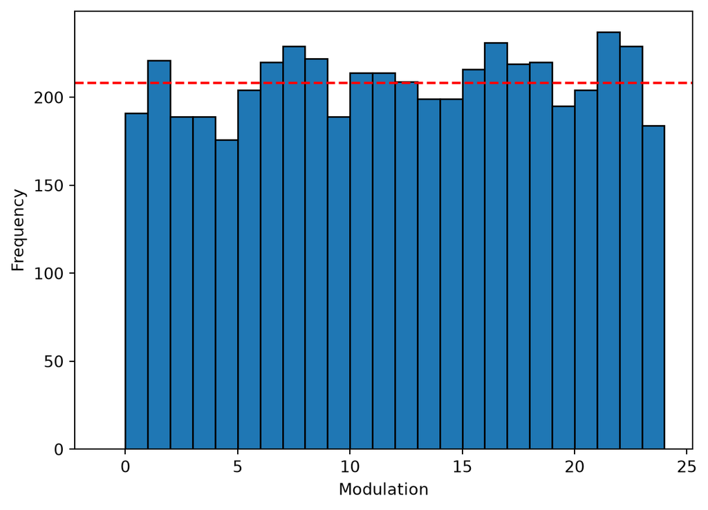

Figure 10: Distribution of Modulation Type in the RadioML dataset

```python
import pandas as pd
import numpy as np
import matplotlib.pyplot as plt
data = pd.read_csv("radioml_features.csv")

bins1 = np.arange(min(data['Modulation'].to_numpy())-1,max(data["Modulation"].to_numpy())+2)


plt.hist(data['Modulation'].to_numpy(),bins=bins1,edgecolor='black')
counts = []
for val in list(set(data["Modulation"].to_numpy())):
  counts.append(list(data["Modulation"].to_numpy()).count(val))
plt.ylabel("Frequency")
plt.xlabel("Modulation")
plt.axhline(np.array(counts).mean(),xmin=-30,xmax=30,linestyle='--',color='red')
#plt.title("Response Variable (Signal-to-Noise Ratio) Distribution")
plt.show()
```

Scatter plots are shown to display the distribution of our mean and power features within our dataset (Figure 11 and Figure 12, respectively)

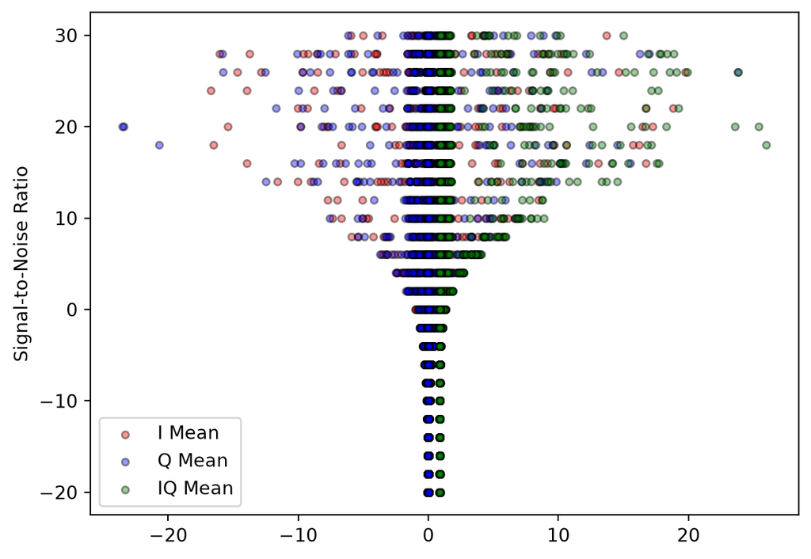

Figure 11: Comparing Means

```python
import pandas as pd
import numpy as np
import matplotlib.pyplot as plt
data = pd.read_csv("radioml_features.csv")
for col,c,name in zip(["I_mean","Q_mean","IQ_mean"],['red','blue','green'],["I Mean","Q Mean","IQ Mean"]):
  plt.scatter(data[col].to_numpy(),data['SNR'].to_numpy(),c=c,edgecolors='black',label=name,alpha=0.4, s=15)
#plt.title("Response Variable (Signal-to-Noise Ratio) Distribution")
plt.legend()
plt.ylabel("Signal-to-Noise Ratio")
plt.show()
```

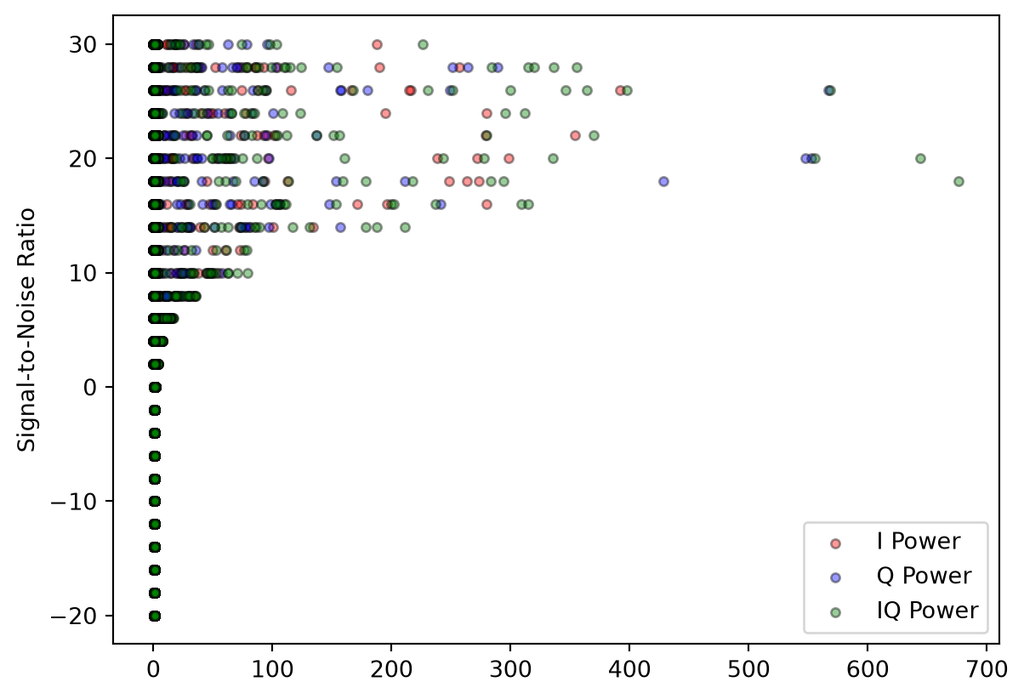

Figure 12: Comparing Powers

```python
import pandas as pd
import numpy as np
import matplotlib.pyplot as plt
data = pd.read_csv("radioml_features.csv")
for col,c,name in zip(["I_power","Q_power","IQ_power"],['red','blue','green'],["I Power","Q Power","IQ Power"]):
  plt.scatter(data[col].to_numpy(),data['SNR'].to_numpy(),c=c,edgecolors='black',label=name,alpha=0.4, s=15)
plt.legend()
plt.ylabel("Signal-to-Noise Ratio")
plt.show()
#plt.title("Response Variable (Signal-to-Noise Ratio) Distribution")
#plt.legend()
#plt.ylabel("Signal-to-Noise Ratio")
#plt.show()
```

## References

Bai, Runbo, Xiumei Qiu, and Maosen Cao. 2009. “Factor Sensitivity Analysis for Multivariable Systems Using Bayesian Neural Networks.” *2009 International Conference on Computational Intelligence and Security* 1: 30–33. https://doi.org/10.1109/CIS.2009.43.

Berger, James O. 2000. “Bayesian Analysis: A Look at Today and Thoughts of Tomorrow.” *Journal of the American Statistical Association* 95 (452): 1269–76. https://doi.org/10.1080/01621459.2000.10474328.

Bishop, Christopher M. 1997. “Bayesian Neural Networks.” *Journal of the Brazilian Computer Society* 4 (1). https://doi.org/10.1590/s0104-65001997000200006.

*Electronic Warfare*. n.d. Accessed September 28, 2026. https://apps.dtic.mil/landingpage/maint.html.

Hernandez-Lobato, Jose Miguel, and Ryan Adams. 2015. “Probabilistic Backpropagation for Scalable Learning of Bayesian Neural Networks.” In *Proceedings of the 32nd International Conference on Machine Learning*, edited by Francis Bach and David Blei, vol. 37. Proceedings of Machine Learning Research. PMLR. https://proceedings.mlr.press/v37/hernandez-lobatoc15.html.

Jere, Shashank, Ying Wang, Ishan Aryendu, Shehadi Dayekh, and Lingjia Liu. 2024. “Bayesian Inference-Assisted Machine Learning for Near Real-Time Jamming Detection and Classification in 5G New Radio (NR).” *IEEE Transactions on Wireless Communications* 23 (7): 7043–59. https://doi.org/10.1109/TWC.2023.3337058.

Jospin, Laurent Valentin, Hamid Laga, Farid Boussaid, Wray Buntine, and Mohammed Bennamoun. 2022. “Hands-on Bayesian Neural Networks—a Tutorial for Deep Learning Users.” *IEEE Computational Intelligence Magazine* 17 (2): 29–48. https://doi.org/10.1109/MCI.2022.3155327.

Mullachery, Vikram, Aniruddh Khera, and Amir Husain. 2018. “Bayesian Neural Networks.” *CoRR* abs/1801.07710. http://arxiv.org/abs/1801.07710.

O’Shea, Timothy James, Tamoghna Roy, and T. Charles Clancy. 2018. “Over-the-Air Deep Learning Based Radio Signal Classification.” *IEEE Journal of Selected Topics in Signal Processing* 12 (1): 168–79. https://doi.org/10.1109/jstsp.2018.2797022.

O’Shea, Timothy, and Jakob Hoydis. 2017. “An Introduction to Deep Learning for the Physical Layer.” *IEEE Transactions on Cognitive Communications and Networking* 3 (4): 563–75. https://doi.org/10.1109/TCCN.2017.2758370.

Snoek, Jasper, Oren Rippel, Kevin Swersky, et al. 2015. “Scalable Bayesian Optimization Using Deep Neural Networks.” *International Conference on Machine Learning*, 2171–80.

vgi_admin. 2025. “Drones Vs. Electronic Warfare: Who’s Winning the Battle for the Skies in Ukraine?” In *VGI-9*. https://vgi.com.ua/en/drones-vs-electronic-warfare-whos-winning-the-battle-for-the-skies-in-ukraine/.